# CS5801 Coursework Supporting analysis Template Proforma

### 2.3.5 Percentage Absence x GPA

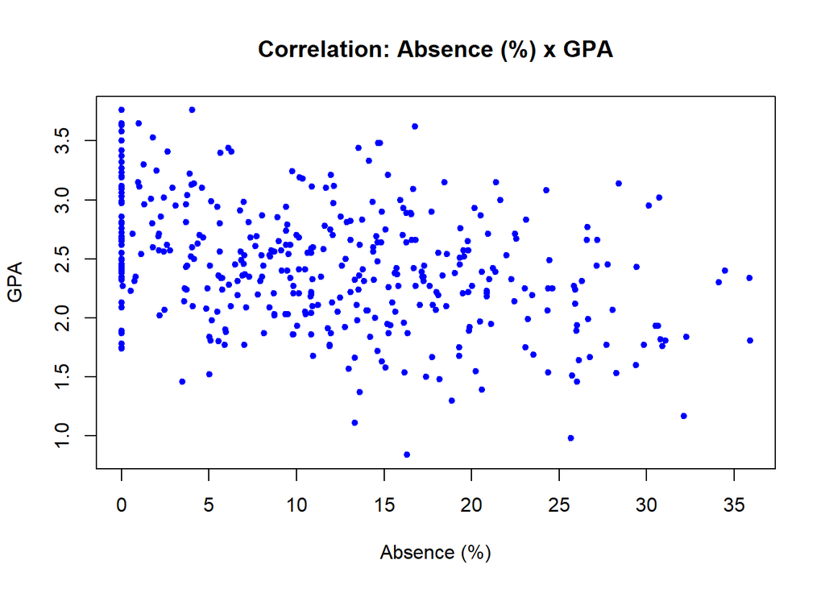

```r
# Ploting the scatter plot between the features
plot(mydf_clean$percentage_absence, mydf_clean$grade_point_average,
     main = "Correlation: Absence (%) x GPA",
     xlab = "Absence (%)",
     ylab = "GPA",
     pch = 20, col = "blue")
```

```r
cor.test(mydf$percentage_absence, mydf$grade_point_average)
```

```
##
##  Pearson's product-moment correlation
##
## data:  mydf$percentage_absence and mydf$grade_point_average
## t = -5.9445, df = 398, p-value = 6.066e-09
## alternative hypothesis: true correlation is not equal to 0
## 95 percent confidence interval:
##  -0.3731664 -0.1929132
## sample estimates:
##        cor
## -0.2855633
```

> Based on the correlation test, we can reject the null hypothesis and confirm that there is a statistically significant correlation between percentage_absence and grade_point_average. This implies that absence rates are associated with GPA scores.

### 2.3.6 Month of Birth x GPA

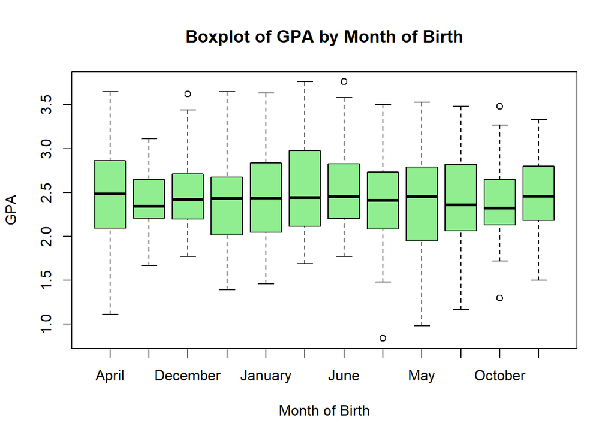

```r
# Create the boxplot
boxplot(grade_point_average ~ month_of_birth,
        data = mydf_clean,
        main = "Boxplot of GPA by Month of Birth",
        xlab = "Month of Birth",
        ylab = "GPA",
        col = c("lightgreen"))
```

From the boxplot we conclude that there’s no apparent relation between the month of birth with the GPA, as the median is almost the same - around 2.5 - in all groups.

For this reason, month of birth won’t be used in the modelling step.

## 2.4 Analyzing possible transformations

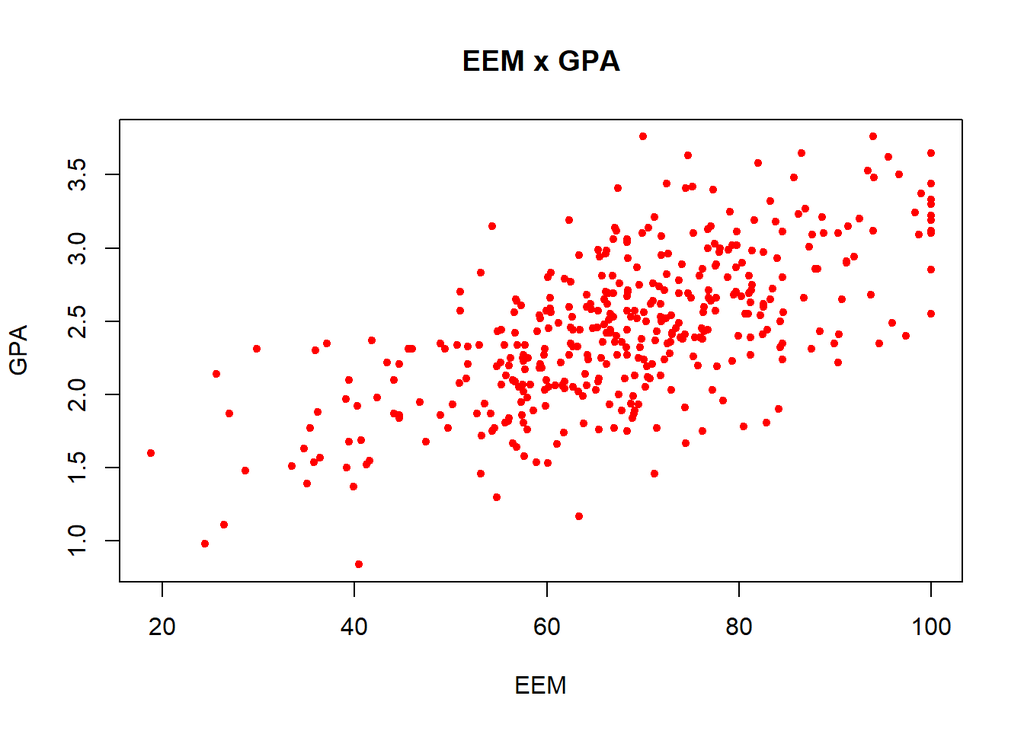

```r
# Ploting the scatter plot between the features
plot(mydf_clean$entry_exam_mark, mydf_clean$grade_point_average,
     main = "EEM x GPA",
     xlab = "EEM",
     ylab = "GPA",
     pch = 20, col = "red")
```

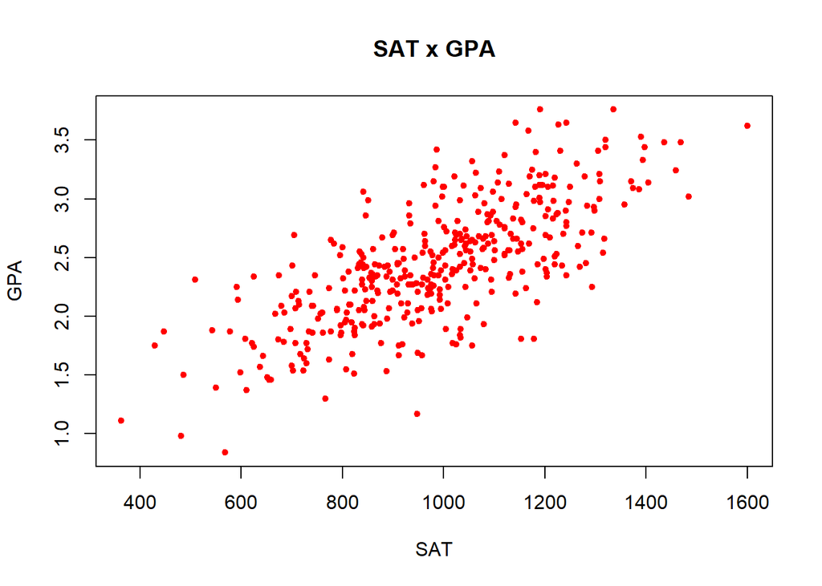

```r
# Ploting the scatter plot between the features
plot(mydf_clean$sat_score, mydf_clean$grade_point_average,
     main = "SAT x GPA",
     xlab = "SAT",
     ylab = "GPA",
     pch = 20, col = "red")
```

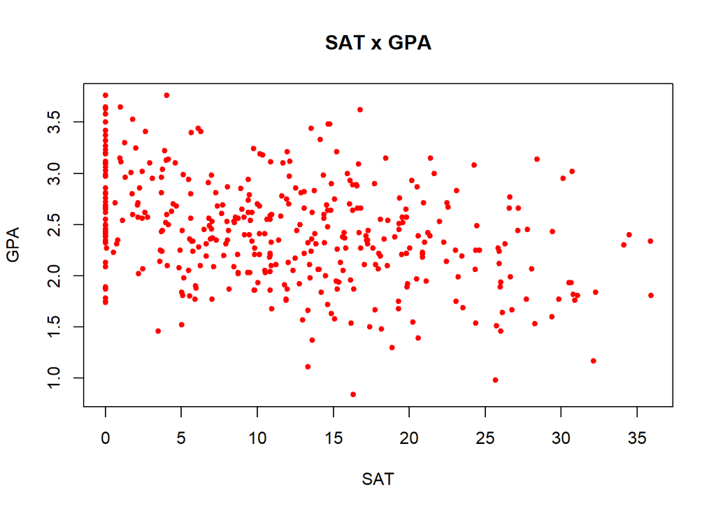

```r
# Ploting the scatter plot between the features
plot(mydf_clean$percentage_absence, mydf_clean$grade_point_average,
     main = "SAT x GPA",
     xlab = "SAT",
     ylab = "GPA",
     pch = 20, col = "red")
```

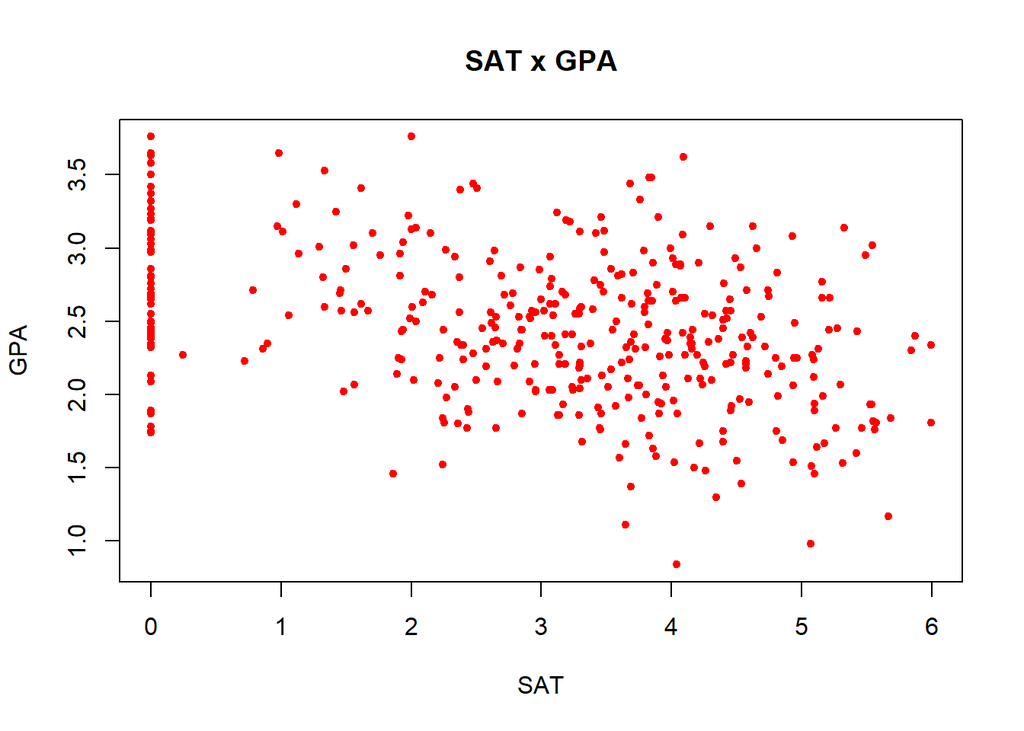

```r
# Ploting the scatter plot between the features
plot(mydf_clean$percentage_absence^(1/2), mydf_clean$grade_point_average,
     main = "SAT x GPA",
     xlab = "SAT",
     ylab = "GPA",
     pch = 20, col = "red")
```

## 2.5 Relationship with Completed Extended Project

### 2.5.1 GPA x Completed Extended Project

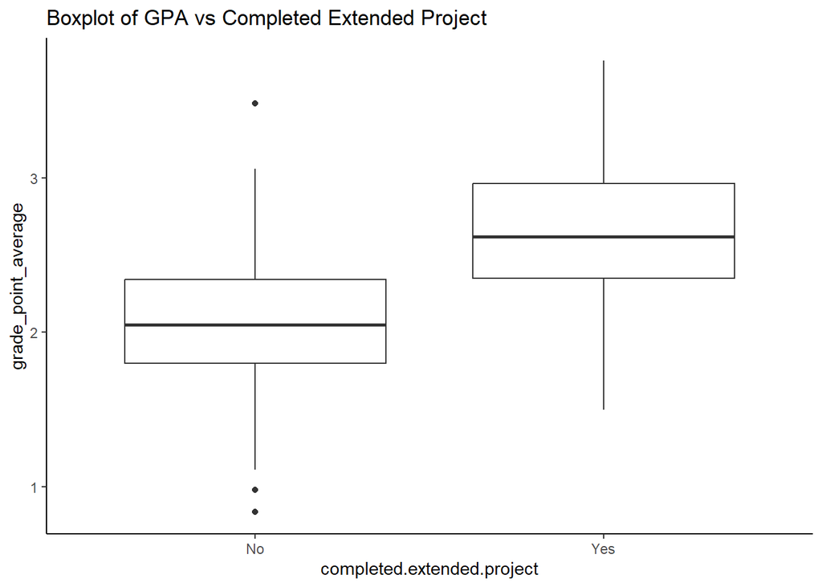

```r
ggplot(mydf_clean, aes(x=completed.extended.project, y=grade_point_average)) + geom_boxplot() + ggtitle("Boxplot of GPA vs Completed Extended Project") + theme_classic()
```

### 2.5.2 SAT Score x Completed Extended Project

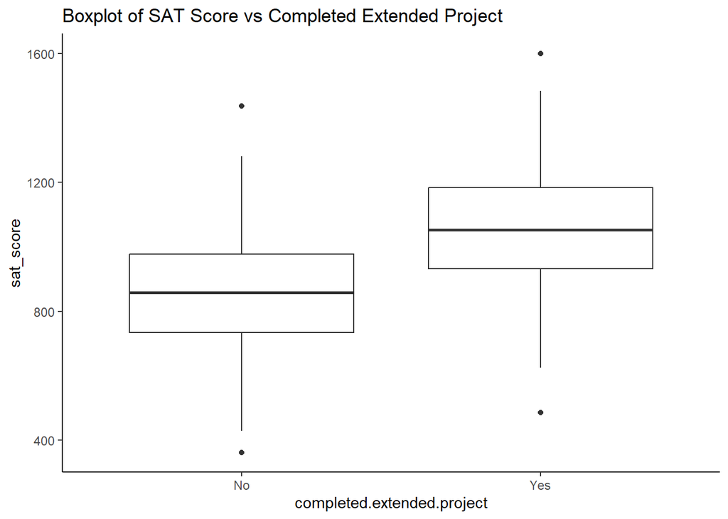

```r
ggplot(mydf_clean, aes(x=completed.extended.project, y=sat_score)) + geom_boxplot() + ggtitle("Boxplot of SAT Score vs Completed Extended Project") + theme_classic()
```

### 2.5.3 Entry Exam Mark x Completed Extended Project

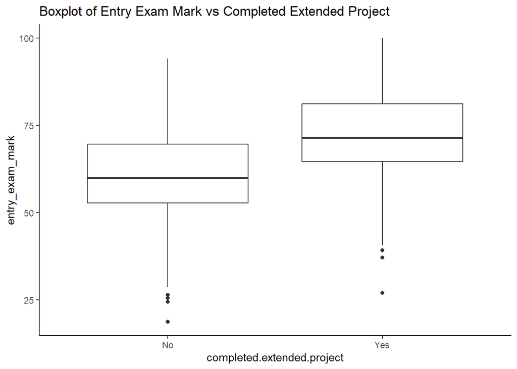

```r
ggplot(mydf_clean, aes(x=completed.extended.project, y=entry_exam_mark)) + geom_boxplot() + ggtitle("Boxplot of Entry Exam Mark vs Completed Extended Project") + theme_classic()
```

### 2.5.4 Commute Method x Completed Extended Project

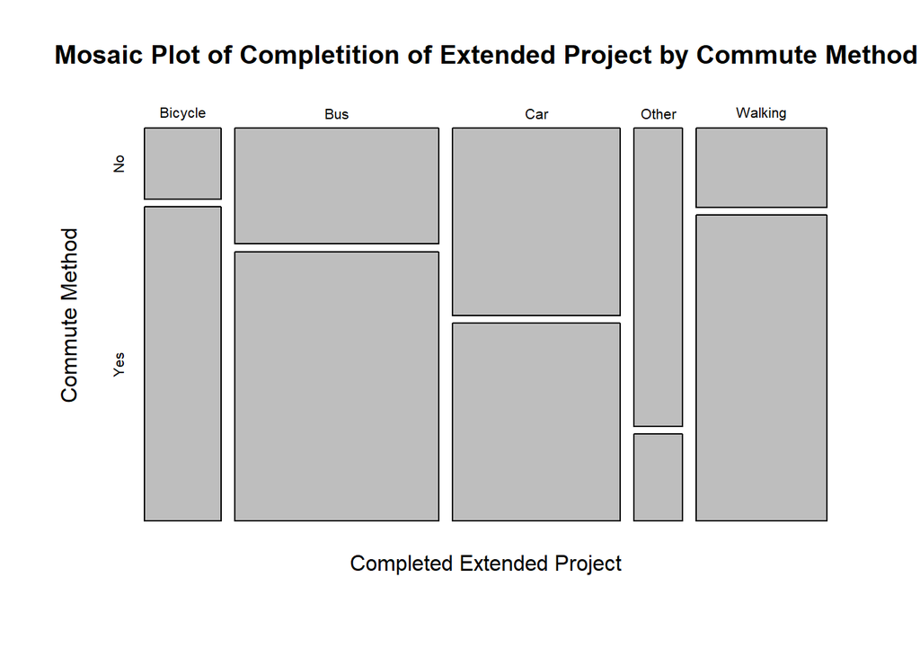

```r
mosaicplot(mydf_clean$commute_method~mydf_clean$completed.extended.project, main = "Mosaic Plot of Completition of Extended Project by Commute Method", ylab="Commute Method", xlab="Completed Extended Project")
```

The difference in proportion between commute methods is very interesting and it might be a good feature for modelling the completition of extended project

### 2.5.5 Free School Meals x Completed Extended Project

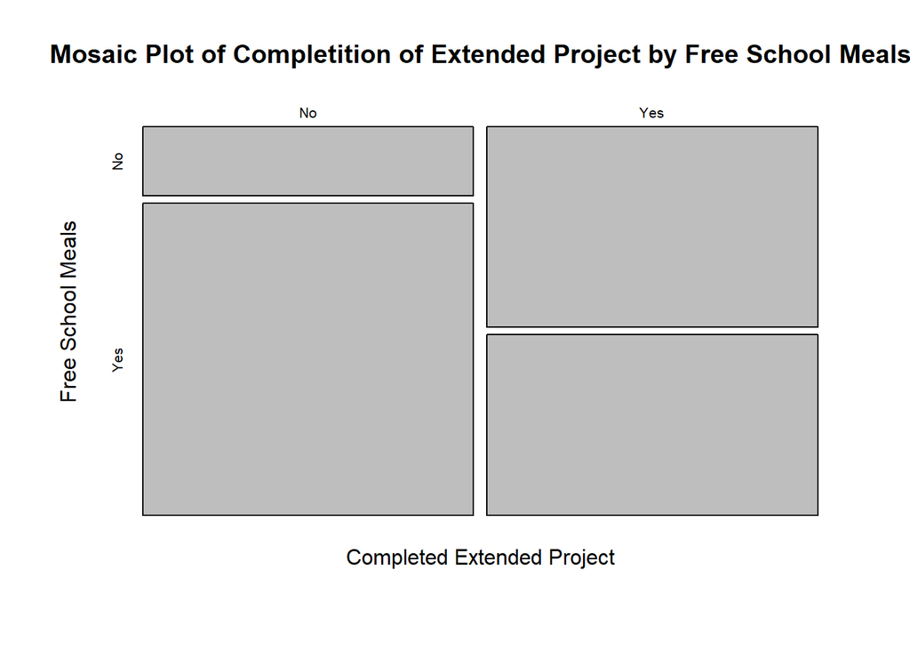

```r
mosaicplot(mydf_clean$free_school_meals~mydf_clean$completed.extended.project, main = "Mosaic Plot of Completition of Extended Project by Free School Meals", ylab="Free School Meals", xlab="Completed Extended Project")
```

### 2.5.6 Percentage Absence x Completed Extended Project

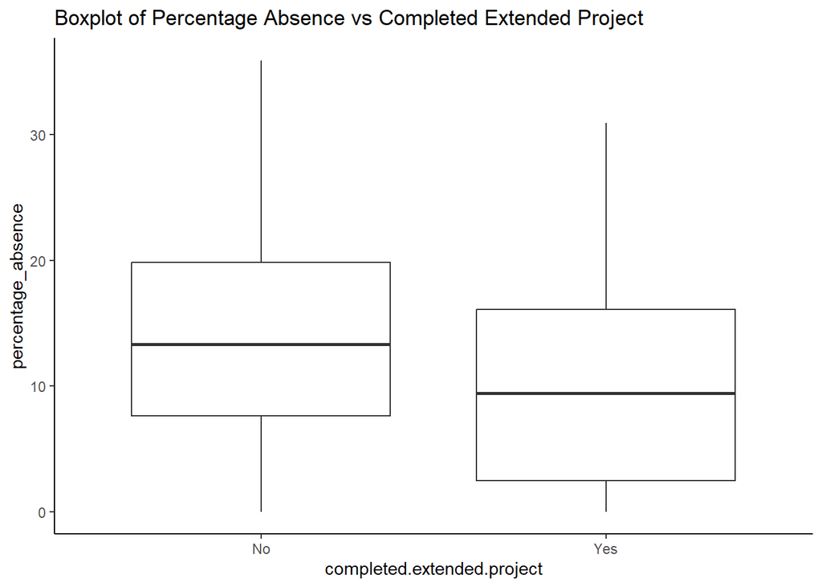

```r
ggplot(mydf_clean, aes(x=completed.extended.project, y=percentage_absence)) + geom_boxplot() + ggtitle("Boxplot of Percentage Absence vs Completed Extended Project") + theme_classic()
```

### 2.5.7 Month of Birth x Completed Extended Project

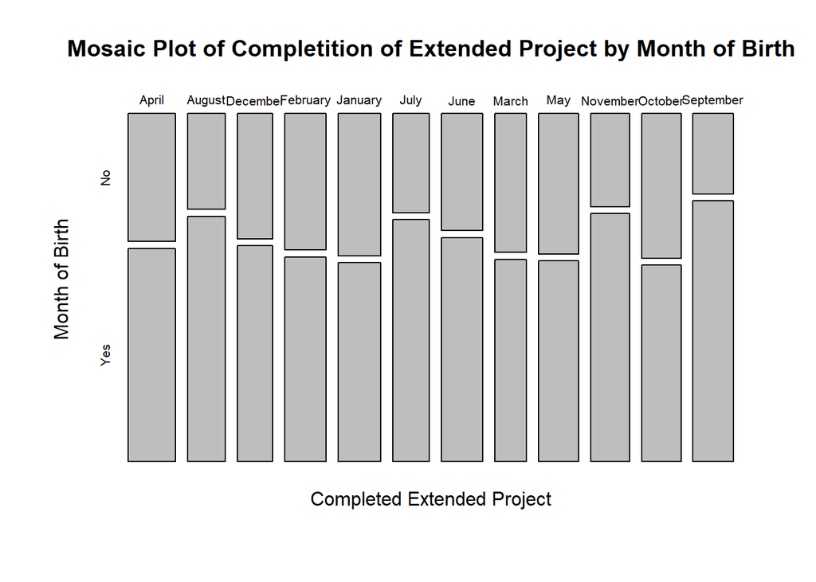

```r
mosaicplot(mydf_clean$month_of_birth~mydf_clean$completed.extended.project, main = "Mosaic Plot of Completition of Extended Project by Month of Birth", ylab="Month of Birth", xlab="Completed Extended Project")
```

# 3. Modelling

## 3.1 Maximal Model

### 3.1.1 Maximal Model - with interactions

```r
# Fit the linear regression model
m1.int <- lm(grade_point_average ~ sat_score*percentage_absence*completed.extended.project, data = mydf_clean)

# Summary of the model to evaluate its performance
summary(m1.int)
```

```
##
## Call:
## lm(formula = grade_point_average ~ sat_score * percentage_absence *
##     completed.extended.project, data = mydf_clean)
##
## Residuals:
##      Min       1Q   Median       3Q      Max
## -0.64121 -0.15339 -0.00969  0.15363  0.78899
##
## Coefficients:
##                                                              Estimate
## (Intercept)                                                 1.059e+00
## sat_score                                                   1.600e-03
## percentage_absence                                         -3.542e-02
## completed.extended.projectYes                              -2.270e-01
## sat_score:percentage_absence                                9.861e-06
## sat_score:completed.extended.projectYes                     4.029e-04
## percentage_absence:completed.extended.projectYes            6.280e-03
## sat_score:percentage_absence:completed.extended.projectYes -9.039e-06
##                                                            Std. Error t value
## (Intercept)                                                 1.712e-01   6.187
## sat_score                                                   2.064e-04   7.750
## percentage_absence                                          1.062e-02  -3.335
## completed.extended.projectYes                               2.220e-01  -1.023
## sat_score:percentage_absence                                1.170e-05   0.843
## sat_score:completed.extended.projectYes                     2.475e-04   1.628
## percentage_absence:completed.extended.projectYes            1.526e-02   0.411
## sat_score:percentage_absence:completed.extended.projectYes  1.539e-05  -0.587
##                                                            Pr(>|t|)
## (Intercept)                                                1.54e-09 ***
## sat_score                                                  7.96e-14 ***
## percentage_absence                                         0.000934 ***
## completed.extended.projectYes                              0.307130
## sat_score:percentage_absence                               0.400010
## sat_score:completed.extended.projectYes                    0.104283
## percentage_absence:completed.extended.projectYes           0.680976
## sat_score:percentage_absence:completed.extended.projectYes 0.557266
## ---
## Signif. codes:  0 '***' 0.001 '**' 0.01 '*' 0.05 '.' 0.1 ' ' 1
##
## Residual standard error: 0.2404 on 392 degrees of freedom
## Multiple R-squared:  0.7842, Adjusted R-squared:  0.7803
## F-statistic: 203.5 on 7 and 392 DF,  p-value: < 2.2e-16
```

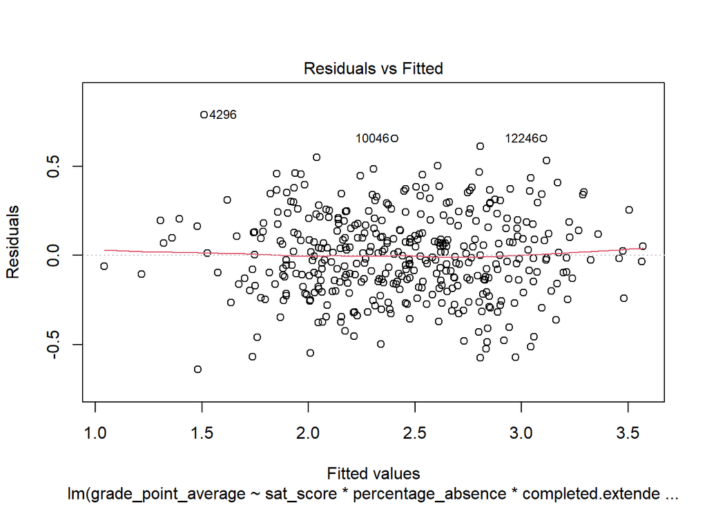

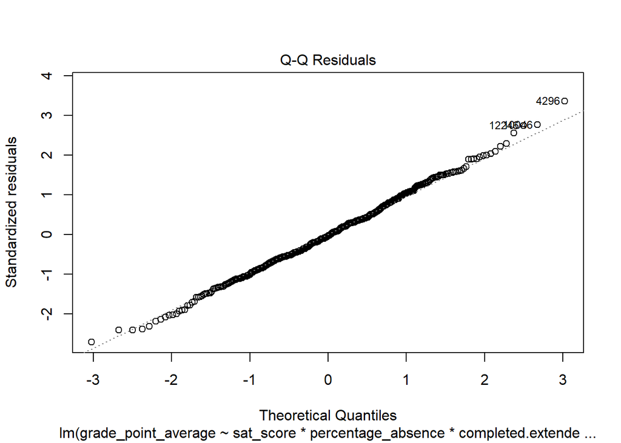

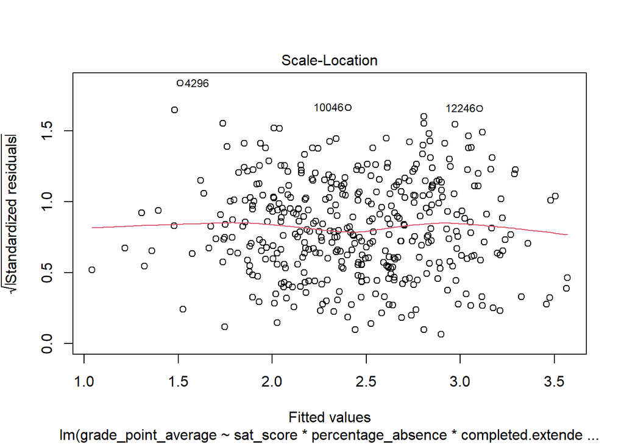

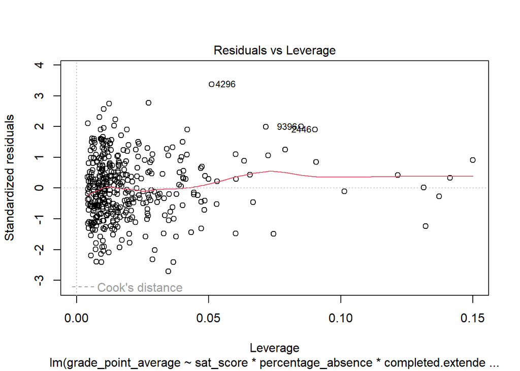

```r
plot(m1.int)
```

### 3.1.2 Maximal Model - without interactions

```r
# Fit the linear regression model
m1 <- lm(grade_point_average ~ entry_exam_mark + sat_score + percentage_absence + free_school_meals + completed.extended.project, data = mydf_clean)

# Summary of the model to evaluate its performance
summary(m1)
```

```
##
## Call:
## lm(formula = grade_point_average ~ entry_exam_mark + sat_score +
##     percentage_absence + free_school_meals + completed.extended.project,
##     data = mydf_clean)
##
## Residuals:
##     Min      1Q  Median      3Q     Max
## -0.5930 -0.1626 -0.0020  0.1647  0.7981
##
## Coefficients:
##                                 Estimate Std. Error t value Pr(>|t|)
## (Intercept)                    0.7468927  0.1078931   6.923 1.81e-11 ***
## entry_exam_mark                0.0003322  0.0011518   0.288 0.773163
## sat_score                      0.0019399  0.0001141  16.995  < 2e-16 ***
## percentage_absence            -0.0276029  0.0017095 -16.147  < 2e-16 ***
## free_school_mealsYes           0.0210284  0.0365513   0.575 0.565409
## completed.extended.projectYes  0.1127515  0.0302260   3.730 0.000219 ***
## ---
## Signif. codes:  0 '***' 0.001 '**' 0.01 '*' 0.05 '.' 0.1 ' ' 1
##
## Residual standard error: 0.2409 on 394 degrees of freedom
## Multiple R-squared:  0.7822, Adjusted R-squared:  0.7794
## F-statistic:   283 on 5 and 394 DF,  p-value: < 2.2e-16
```